# Bayes Aplicado ENIGH

Hector Najera y Curtis Huffman

26/05/2021

# Introducción

Esta nota brinda una introducción bastante elemental a los siguientes tipos de modelos:

- Modelación no multinivel
- Modelación multinivel: Ordenadas al origen
- Modelación multinivel: Ordenadas al origen y pendientes

Con el pretexto de estos modelos, también se aborda el cómputo de los estadísticos de validación cruzada: loo

```r
library(pacman)
p_load(haven, dplyr, brms, bayesplot, tidybayes, ggplot2)
color_scheme_set(scheme = "viridis")
```

```r
D<-read_dta("pobreza_18.dta")
```

# Modelo multinivel y no multinivel

## Modelo de un nivel

Vamos a utilizar datos de la ENIGH 2018. Utlizaremos el nivel educativo, el tamaño del hogar y el de localidad como variables de ajuste. Además vamos a ajustar por la entidad federativa de residencia.

```r
M<-brm(pobreza ~ 1 + factor(niv_edexpjh),
        prior = c(set_prior("normal(0,10)", class = "b")),
        family="bernoulli", chains=4, cores=4, iter=2000,  threads = threading(14, grainsize = 100),backend = "cmdstanr", data=D)
```

[output not shown]

[output cut: 43 more lines]

```
## Chain 1 Iteration: 1900 / 2000 [ 95%]  (Sampling)
## Chain 2 Iteration: 1700 / 2000 [ 85%]  (Sampling)
## Chain 4 Iteration: 1900 / 2000 [ 95%]  (Sampling)
## Chain 2 Iteration: 1800 / 2000 [ 90%]  (Sampling)
## Chain 1 Iteration: 2000 / 2000 [100%]  (Sampling)
## Chain 4 Iteration: 2000 / 2000 [100%]  (Sampling)
## Chain 1 finished in 6.9 seconds.
## Chain 4 finished in 7.0 seconds.
## Chain 2 Iteration: 1900 / 2000 [ 95%]  (Sampling)
## Chain 2 Iteration: 2000 / 2000 [100%]  (Sampling)
## Chain 2 finished in 7.5 seconds.
##
## All 4 chains finished successfully.
## Mean chain execution time: 6.9 seconds.
## Total execution time: 7.7 seconds.
```

```r
summary(M)
```

```
##  Family: bernoulli
##   Links: mu = logit
## Formula: pobreza ~ 1 + factor(niv_edexpjh)
##    Data: D (Number of observations: 19999)
##   Draws: 4 chains, each with iter = 2000; warmup = 1000; thin = 1;
##          total post-warmup draws = 4000
##
## Population-Level Effects:
##                    Estimate Est.Error l-95% CI u-95% CI Rhat Bulk_ESS Tail_ESS
## Intercept              0.31      0.03     0.25     0.37 1.00     2986     2599
## factorniv_edexpjh1    -0.37      0.04    -0.46    -0.29 1.00     3303     3274
## factorniv_edexpjh2    -0.82      0.04    -0.90    -0.74 1.00     2983     2616
## factorniv_edexpjh3    -1.53      0.05    -1.64    -1.43 1.00     3518     3102
## factorniv_edexpjh4    -2.69      0.09    -2.86    -2.52 1.00     4010     3299
##
## Draws were sampled using sample(hmc). For each parameter, Bulk_ESS
## and Tail_ESS are effective sample size measures, and Rhat is the potential
## scale reduction factor on split chains (at convergence, Rhat = 1).
```

```r
M1<-brm(pobreza ~ 1 + factor(niv_edexpjh) + tamhogesc + factor(tam_loc) + factor(ent),
        prior = c(set_prior("normal(0,10)", class = "b")),
        family="bernoulli", chains=4, cores=4, iter=2000,  threads = threading(14, grainsize = 100),backend = "cmdstanr", data=D)
```

[output not shown]

[output cut: 43 more lines]

```
## Chain 1 Iteration: 1800 / 2000 [ 90%]  (Sampling)
## Chain 3 Iteration: 1800 / 2000 [ 90%]  (Sampling)
## Chain 2 Iteration: 1900 / 2000 [ 95%]  (Sampling)
## Chain 1 Iteration: 1900 / 2000 [ 95%]  (Sampling)
## Chain 3 Iteration: 1900 / 2000 [ 95%]  (Sampling)
## Chain 2 Iteration: 2000 / 2000 [100%]  (Sampling)
## Chain 2 finished in 13.6 seconds.
## Chain 1 Iteration: 2000 / 2000 [100%]  (Sampling)
## Chain 3 Iteration: 2000 / 2000 [100%]  (Sampling)
## Chain 1 finished in 13.9 seconds.
## Chain 3 finished in 13.9 seconds.
##
## All 4 chains finished successfully.
## Mean chain execution time: 13.5 seconds.
## Total execution time: 14.1 seconds.
```

```r
summary(M1)
```

```
##  Family: bernoulli
##   Links: mu = logit
## Formula: pobreza ~ 1 + factor(niv_edexpjh) + tamhogesc + factor(tam_loc) + factor(ent)
##    Data: D (Number of observations: 19999)
##   Draws: 4 chains, each with iter = 2000; warmup = 1000; thin = 1;
##          total post-warmup draws = 4000
##
## Population-Level Effects:
##                    Estimate Est.Error l-95% CI u-95% CI Rhat Bulk_ESS Tail_ESS
## Intercept             -1.36      0.11    -1.58    -1.15 1.01      314      630
## factorniv_edexpjh1    -0.29      0.04    -0.38    -0.20 1.00     2814     2910
## factorniv_edexpjh2    -0.65      0.04    -0.73    -0.56 1.00     2490     2920
## factorniv_edexpjh3    -1.40      0.06    -1.51    -1.28 1.00     2727     2874
## factorniv_edexpjh4    -2.51      0.09    -2.69    -2.33 1.00     2943     2829
## tamhogesc              0.14      0.01     0.12     0.16 1.00     4283     3203
## factortam_loc2         0.44      0.06     0.33     0.55 1.00     2748     2924
## factortam_loc3         0.67      0.05     0.57     0.78 1.00     2643     2874
## factortam_loc4         0.23      0.04     0.14     0.31 1.00     2663     2523
## factorent2            -0.21      0.12    -0.46     0.03 1.00      419     1214
## factorent3            -0.18      0.14    -0.46     0.09 1.00      515     1185
## factorent4             1.01      0.14     0.74     1.28 1.00      484      959
## factorent5            -0.16      0.13    -0.41     0.09 1.00      405      995
## factorent6             0.46      0.12     0.21     0.69 1.00      408     1053
## factorent7             2.30      0.14     2.03     2.58 1.00      525     1177
## factorent8             0.46      0.12     0.23     0.70 1.00      390      828
## factorent9             0.60      0.13     0.33     0.86 1.00      490     1151
## factorent10            0.64      0.12     0.40     0.89 1.00      433     1066
## factorent11            0.85      0.12     0.61     1.08 1.00      414      847
## factorent12            1.90      0.13     1.64     2.16 1.00      472     1018
## factorent13            0.70      0.13     0.44     0.96 1.00      450     1020
## factorent14            0.09      0.14    -0.19     0.35 1.00      455     1156
## factorent15            1.00      0.12     0.77     1.23 1.00      371      842
## factorent16            0.87      0.13     0.62     1.13 1.00      495      937
## factorent17            1.24      0.13     0.97     1.50 1.00      449     1098
## factorent18            0.45      0.14     0.18     0.73 1.00      509     1226
## factorent19           -0.38      0.13    -0.65    -0.12 1.00      450     1076
## factorent20            1.82      0.13     1.57     2.09 1.00      485     1150
## factorent21            1.61      0.13     1.34     1.87 1.00      470      853
## factorent22            0.14      0.12    -0.10     0.37 1.00      393      875
## factorent23            0.19      0.15    -0.11     0.48 1.00      584     1072
## factorent24            1.00      0.13     0.75     1.24 1.00      476     1031
## factorent25            0.51      0.12     0.27     0.76 1.00      399     1147
## factorent26            0.51      0.14     0.23     0.77 1.00      459      982
## factorent27            1.53      0.13     1.27     1.79 1.00      490     1085
## factorent28            0.91      0.14     0.64     1.19 1.00      508     1296
## factorent29            1.03      0.13     0.79     1.28 1.00      424      889
## factorent30            1.76      0.13     1.52     2.02 1.00      472     1086
## factorent31            0.71      0.12     0.46     0.95 1.00      424      713
## factorent32            1.02      0.12     0.77     1.27 1.00      431      888
##
## Draws were sampled using sample(hmc). For each parameter, Bulk_ESS
## and Tail_ESS are effective sample size measures, and Rhat is the potential
## scale reduction factor on split chains (at convergence, Rhat = 1).
```

¿Incrementa Chiapas el riesgo de vivir en pobreza, relativo a Aguascalientes?

```r
get_variables(M1)
```

```
##  [1] "b_Intercept"          "b_factorniv_edexpjh1" "b_factorniv_edexpjh2"
##  [4] "b_factorniv_edexpjh3" "b_factorniv_edexpjh4" "b_tamhogesc"
##  [7] "b_factortam_loc2"     "b_factortam_loc3"     "b_factortam_loc4"
## [10] "b_factorent2"         "b_factorent3"         "b_factorent4"
## [13] "b_factorent5"         "b_factorent6"         "b_factorent7"
## [16] "b_factorent8"         "b_factorent9"         "b_factorent10"
## [19] "b_factorent11"        "b_factorent12"        "b_factorent13"
## [22] "b_factorent14"        "b_factorent15"        "b_factorent16"
## [25] "b_factorent17"        "b_factorent18"        "b_factorent19"
## [28] "b_factorent20"        "b_factorent21"        "b_factorent22"
## [31] "b_factorent23"        "b_factorent24"        "b_factorent25"
## [34] "b_factorent26"        "b_factorent27"        "b_factorent28"
## [37] "b_factorent29"        "b_factorent30"        "b_factorent31"
## [40] "b_factorent32"        "lprior"               "lp__"
## [43] "accept_stat__"        "treedepth__"          "stepsize__"
## [46] "divergent__"          "n_leapfrog__"         "energy__"
```

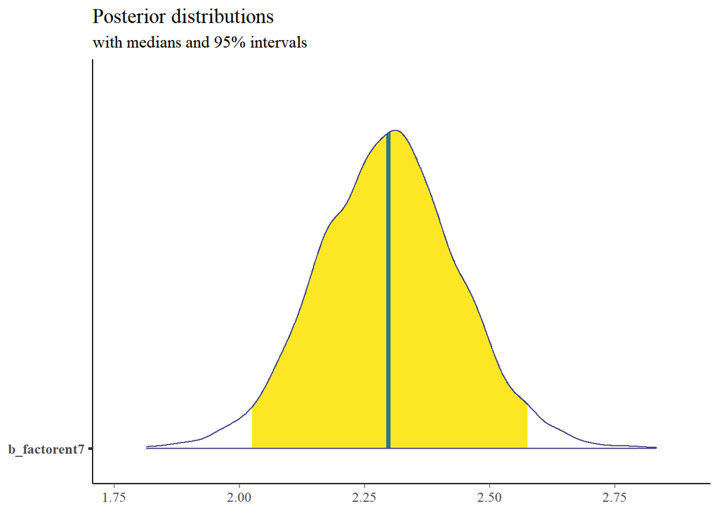

```r
plot_title <- ggtitle("Posterior distributions",
                      "with medians and 95% intervals")
mcmc_areas(M1,
           pars = c( "b_factorent7"),
           prob = 0.95) + plot_title
```

## Chequeos predictivos posteriores

Quisieramos saber si el modelo hace buenas predicciones de las proporciones población pobre y no pobre. Para ello podemos utilizar la función `pp_check`. Dado que se trata de una variable categórica vamos a solicitar una gráfica de barras.

Como puede apreciarse, el modelo hace un muy buen trabjo en predecir las proporciones de población pobre y no pobre.

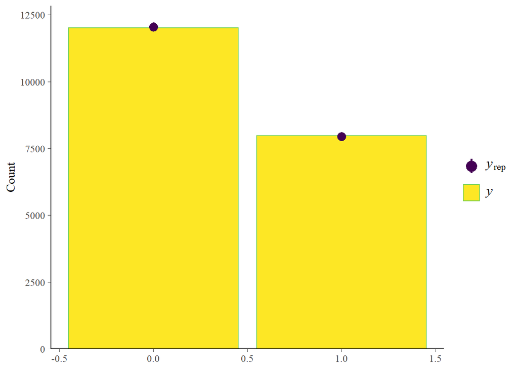

```r
pp_check(M1, ndraws = 11, type = "bars")
```

## Compración de modelos

*The Pareto k estimate is a diagnostic for Pareto smoothed importance sampling (PSIS), which is used to compute components of elpd_loo. In importance-sampling LOO (the full posterior distribution is used as the proposal distribution). The Pareto k diagnostic estimates how far an individual leave-one-out distribution is from the full distribution. If leaving out an observation changes the posterior too much then importance sampling is not able to give reliable estimate. If k<0.5, then the corresponding component of elpd_loo is estimated with high accuracy. If 0.5<k<0.7 the accuracy is lower, but still ok. If k>0.7, then importance sampling is not able to provide useful estimate for that component/observation. Pareto k is also useful as a measure of influence of an observation. Highly influential observations have high k values. **Very high k values often indicate model misspecification, outliers or mistakes in data processing.***

```r
M.loo<-loo(M)
M1.loo<-loo(M1)
M.loo
```

```
##
## Computed from 4000 by 19999 log-likelihood matrix
##
##          Estimate   SE
## elpd_loo -12418.5 48.3
## p_loo         5.0  0.1
## looic     24837.0 96.5
## ------
## Monte Carlo SE of elpd_loo is 0.0.
##
## All Pareto k estimates are good (k < 0.5).
## See help('pareto-k-diagnostic') for details.
```

```r
M1.loo
```

```
##
## Computed from 4000 by 19999 log-likelihood matrix
##
##          Estimate    SE
## elpd_loo -11329.5  62.6
## p_loo        40.1   0.3
## looic     22659.0 125.3
## ------
## Monte Carlo SE of elpd_loo is 0.1.
##
## All Pareto k estimates are good (k < 0.5).
## See help('pareto-k-diagnostic') for details.
```

*When using loo_compare(), the returned matrix will have one row per model and several columns of estimates. The values in the elpd_diff and se_diff columns of the returned matrix are computed by making pairwise comparisons between each model and the model with the largest ELPD (the model in the first row). For this reason the elpd_diff column will always have the value 0 in the first row (i.e., the difference between the preferred model and itself) and negative values in subsequent rows for the remaining models.*

El modelo con el valor más bajo “elpd_diff” es el peor

```r
loo_compare(M1.loo,M.loo)
```

```
##    elpd_diff se_diff
## M1     0.0       0.0
## M  -1089.0      45.4
```

## Multinivel

```r
M1.b<-brm(pobreza ~ 1 + factor(niv_edexpjh) + tamhogesc + factor(tam_loc) + (1 | ent),
        prior = c(set_prior("normal(0,10)", class = "b"),
                  set_prior("normal(0,5)", class = "sd")),
        family="bernoulli", chains=4, cores=4, iter=2000,  threads = threading(14, grainsize = 100),backend = "cmdstanr", data=D)
```

[output not shown]

[output cut: 43 more lines]

```
## Chain 3 Iteration: 1600 / 2000 [ 80%]  (Sampling)
## Chain 1 Iteration: 1900 / 2000 [ 95%]  (Sampling)
## Chain 2 Iteration: 2000 / 2000 [100%]  (Sampling)
## Chain 2 finished in 40.3 seconds.
## Chain 1 Iteration: 2000 / 2000 [100%]  (Sampling)
## Chain 3 Iteration: 1700 / 2000 [ 85%]  (Sampling)
## Chain 1 finished in 41.1 seconds.
## Chain 3 Iteration: 1800 / 2000 [ 90%]  (Sampling)
## Chain 3 Iteration: 1900 / 2000 [ 95%]  (Sampling)
## Chain 3 Iteration: 2000 / 2000 [100%]  (Sampling)
## Chain 3 finished in 45.6 seconds.
##
## All 4 chains finished successfully.
## Mean chain execution time: 41.0 seconds.
## Total execution time: 45.8 seconds.
```

```r
summary(M1.b)
```

```
##  Family: bernoulli
##   Links: mu = logit
## Formula: pobreza ~ 1 + factor(niv_edexpjh) + tamhogesc + factor(tam_loc) + (1 | ent)
##    Data: D (Number of observations: 19999)
##   Draws: 4 chains, each with iter = 2000; warmup = 1000; thin = 1;
##          total post-warmup draws = 4000
##
## Group-Level Effects:
## ~ent (Number of levels: 32)
##               Estimate Est.Error l-95% CI u-95% CI Rhat Bulk_ESS Tail_ESS
## sd(Intercept)     0.69      0.10     0.53     0.91 1.01      343      656
##
## Population-Level Effects:
##                    Estimate Est.Error l-95% CI u-95% CI Rhat Bulk_ESS Tail_ESS
## Intercept             -0.59      0.14    -0.85    -0.31 1.02      246      501
## factorniv_edexpjh1    -0.29      0.05    -0.38    -0.21 1.00     1839     2518
## factorniv_edexpjh2    -0.65      0.04    -0.73    -0.57 1.00     1837     2258
## factorniv_edexpjh3    -1.40      0.06    -1.51    -1.28 1.00     2132     2677
## factorniv_edexpjh4    -2.50      0.09    -2.68    -2.32 1.00     2406     2703
## tamhogesc              0.14      0.01     0.12     0.16 1.00     2976     2783
## factortam_loc2         0.44      0.06     0.33     0.55 1.00     1971     2093
## factortam_loc3         0.67      0.05     0.57     0.78 1.00     2170     2524
## factortam_loc4         0.23      0.04     0.15     0.31 1.00     2007     2306
##
## Draws were sampled using sample(hmc). For each parameter, Bulk_ESS
## and Tail_ESS are effective sample size measures, and Rhat is the potential
## scale reduction factor on split chains (at convergence, Rhat = 1).
```

A continuación graficamos las distribuciones posteriores del efecto aleatorio para cada entidad. Tenemos que hacer varias manipulaciones de las MCMC para poder hacerlo. Observamos las diferencias en efecto para los diferentes estados.

```r
ranef(M1.b, groups="ent", probs = 0.5)
```

```
## $ent
## , , Intercept
##
##       Estimate Est.Error         Q50
## 1  -0.76352689 0.1547645 -0.76112300
## 2  -0.96762245 0.1506482 -0.96292200
## 3  -0.93052455 0.1620339 -0.92782200
## 4   0.23028140 0.1566067  0.23219450
## 5  -0.92319356 0.1515168 -0.91966400
## 6  -0.31386826 0.1472495 -0.31118650
## 7   1.48543161 0.1620382  1.48869500
## 8  -0.30687322 0.1443043 -0.30586800
## 9  -0.16889030 0.1574148 -0.16809800
## 10 -0.13202605 0.1481848 -0.12966100
## 11  0.07206929 0.1444158  0.07667570
```

[output cut: 21 more lines]

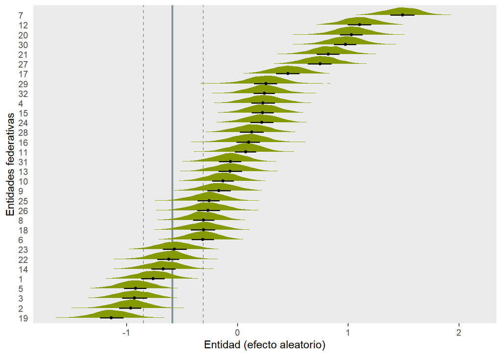

```r
library(stringr)

M1.b %>%
  spread_draws(r_ent[ent,]) %>%
  # add the grand mean to the group-specific deviations
  mutate(mu = r_ent) %>%
  ungroup() %>%
  mutate(ent = str_replace_all(ent, "[.]", " ")) %>%

  # plot
  ggplot(aes(x = mu, y = reorder(ent, mu))) +
  geom_vline(xintercept = fixef(M1.b)[1, 1], color = "#839496", size = 1) +
  geom_vline(xintercept = fixef(M1.b)[1, 3:4], color = "#839496", linetype = 2) +
  geom_halfeyeh(.width = .5, size = 2/3, fill = "#859900") +
  labs(x = expression("Entidad (efecto aleatorio)"),
       y = "Entidades federativas") +
  theme(panel.grid   = element_blank(),
        axis.ticks.y = element_blank(),
        axis.text.y  = element_text(hjust = 0),
        text = element_text(family = "Ubuntu"))
```

# Evaluación de modelos con cross-validation y loo

*The Pareto k estimate is a diagnostic for Pareto smoothed importance sampling (PSIS), which is used to compute components of elpd_loo. In importance-sampling LOO (the full posterior distribution is used as the proposal distribution). The Pareto k diagnostic estimates how far an individual leave-one-out distribution is from the full distribution. If leaving out an observation changes the posterior too much then importance sampling is not able to give reliable estimate. If k<0.5, then the corresponding component of elpd_loo is estimated with high accuracy. If 0.5<k<0.7 the accuracy is lower, but still ok. If k>0.7, then importance sampling is not able to provide useful estimate for that component/observation. Pareto k is also useful as a measure of influence of an observation. Highly influential observations have high k values. **Very high k values often indicate model misspecification, outliers or mistakes in data processing.***

```r
M1.b.loo<-loo(M1.b)
M1.b.loo
```

```
##
## Computed from 4000 by 19999 log-likelihood matrix
##
##          Estimate    SE
## elpd_loo -11329.5  62.2
## p_loo        39.7   0.3
## looic     22659.0 124.3
## ------
## Monte Carlo SE of elpd_loo is 0.1.
##
## All Pareto k estimates are good (k < 0.5).
## See help('pareto-k-diagnostic') for details.
```

*When using loo_compare(), the returned matrix will have one row per model and several columns of estimates. The values in the elpd_diff and se_diff columns of the returned matrix are computed by making pairwise comparisons between each model and the model with the largest ELPD (the model in the first row). For this reason the elpd_diff column will always have the value 0 in the first row (i.e., the difference between the preferred model and itself) and negative values in subsequent rows for the remaining models.*

El modelo con el valor más bajo “elpd_diff” es el peor

El modelo de referencia “0” es el mejor. La diferencia es trivial entre ambos.

```r
loo_compare(M1.loo,M1.b.loo,M.loo)
```

```
##      elpd_diff se_diff
## M1.b     0.0       0.0
## M1       0.0       0.8
## M    -1089.0      44.7
```

## Pendientes aleatorias (al interior de cada estado)

```r
M1.c<-brm(pobreza ~ 1 + factor(niv_edexpjh) + tamhogesc + factor(tam_loc) + (1 + niv_edexpjh | ent),
        prior = c(set_prior("normal(0,10)", class = "b"),
                  set_prior("normal(0,5)", class = "sd")),
        family="bernoulli", chains=2, cores=2, iter=2000,  threads = threading(14, grainsize = 100),backend = "cmdstanr", data=D)
```

[output not shown]

```r
summary(M1.c)
```

```
##  Family: bernoulli
##   Links: mu = logit
## Formula: pobreza ~ 1 + factor(niv_edexpjh) + tamhogesc + factor(tam_loc) + (1 + niv_edexpjh | ent)
##    Data: D (Number of observations: 19999)
##   Draws: 2 chains, each with iter = 2000; warmup = 1000; thin = 1;
##          total post-warmup draws = 2000
##
## Group-Level Effects:
## ~ent (Number of levels: 32)
##                            Estimate Est.Error l-95% CI u-95% CI Rhat Bulk_ESS
## sd(Intercept)                  0.77      0.11     0.60     1.00 1.00      397
## sd(niv_edexpjh)                0.09      0.02     0.05     0.14 1.00      851
## cor(Intercept,niv_edexpjh)    -0.64      0.17    -0.90    -0.26 1.00     1347
##                            Tail_ESS
## sd(Intercept)                   771
## sd(niv_edexpjh)                1034
## cor(Intercept,niv_edexpjh)     1144
##
## Population-Level Effects:
##                    Estimate Est.Error l-95% CI u-95% CI Rhat Bulk_ESS Tail_ESS
## Intercept             -0.59      0.15    -0.91    -0.30 1.02      215      366
## factorniv_edexpjh1    -0.29      0.05    -0.39    -0.20 1.00     1109     1409
## factorniv_edexpjh2    -0.65      0.06    -0.76    -0.54 1.00      513      894
## factorniv_edexpjh3    -1.39      0.08    -1.54    -1.23 1.01      425      765
## factorniv_edexpjh4    -2.49      0.11    -2.71    -2.27 1.00      536     1060
## tamhogesc              0.14      0.01     0.13     0.16 1.00     3218     1285
## factortam_loc2         0.45      0.06     0.35     0.56 1.00     2279     1513
## factortam_loc3         0.68      0.05     0.57     0.78 1.00     2257     1311
## factortam_loc4         0.23      0.04     0.15     0.32 1.00     2071     1531
##
## Draws were sampled using sample(hmc). For each parameter, Bulk_ESS
## and Tail_ESS are effective sample size measures, and Rhat is the potential
## scale reduction factor on split chains (at convergence, Rhat = 1).
```

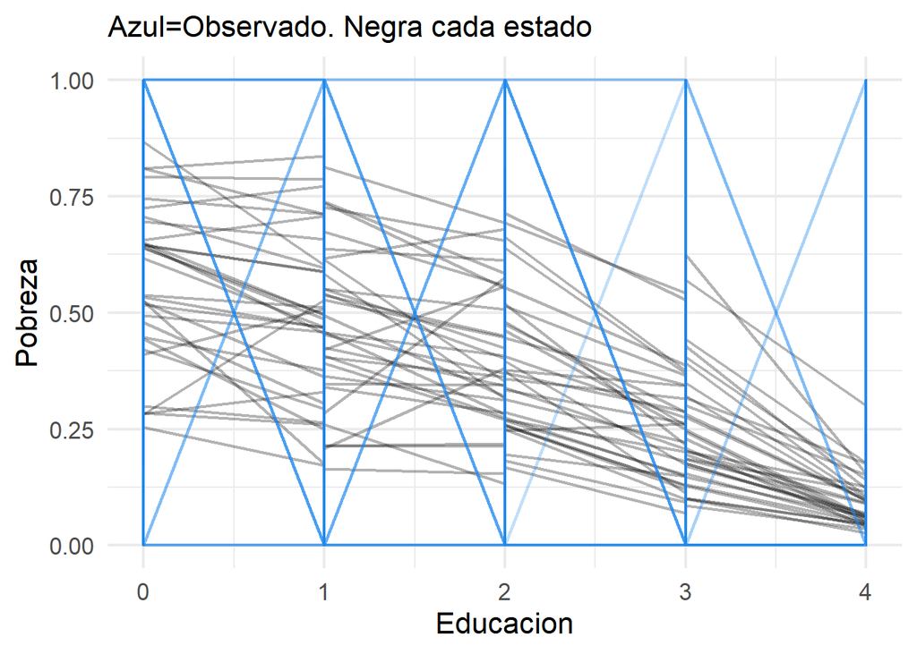

```r
M1.c$data %>%
  bind_cols(as_tibble(fitted(M1.c))) %>%
  ggplot() +
  geom_line(aes(x = niv_edexpjh, y = Estimate, group = ent), size = .75, alpha = .30) +
  geom_line(aes(x = niv_edexpjh, y = pobreza, group = ent), size = .75, alpha = .15, color = "dodgerblue2") +
  labs(x = "Educacion",
       y = "Pobreza",
       subtitle = "Azul=Observado. Negra cada estado") +
  theme_minimal(base_size = 16) +
  theme(plot.title = element_text(hjust = .5))
```

```r
M1.c.loo<-loo(M1.c)
loo_compare(M1.b.loo, M1.c.loo)
```

```
##      elpd_diff se_diff
## M1.c  0.0       0.0
## M1.b -9.1       4.7
```

# Predicción

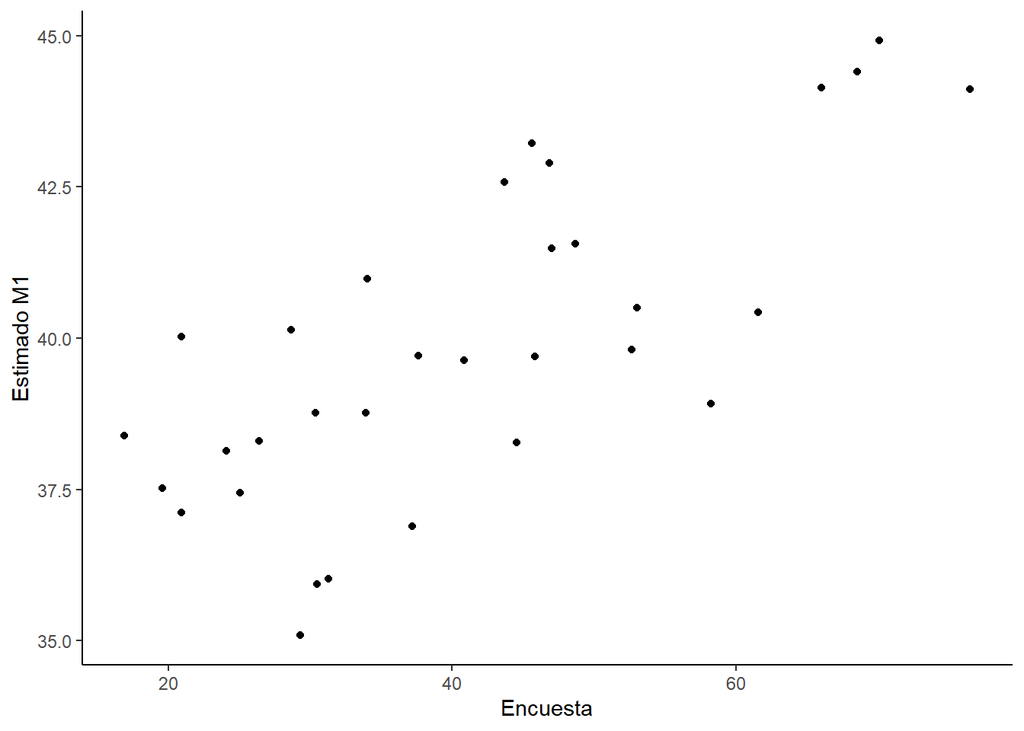

```r
D$prM1<-predict(M, newdata=D ,ndraws=300)
D$prM1.c<-predict(M1.c, newdata=D ,ndraws=300)

D %>% group_by(ent) %>% summarise(SPent=mean(pobreza, na.rm=T), M1Pent=mean(prM1[,1], na.rm=T),
                                  M1.cPent=mean(prM1.c[,1], na.rm=T)) -> Prent

ggplot(Prent, aes(SPent*100, M1Pent*100)) + geom_point() + theme_classic() + labs(y="Estimado M1", x="Encuesta")
```

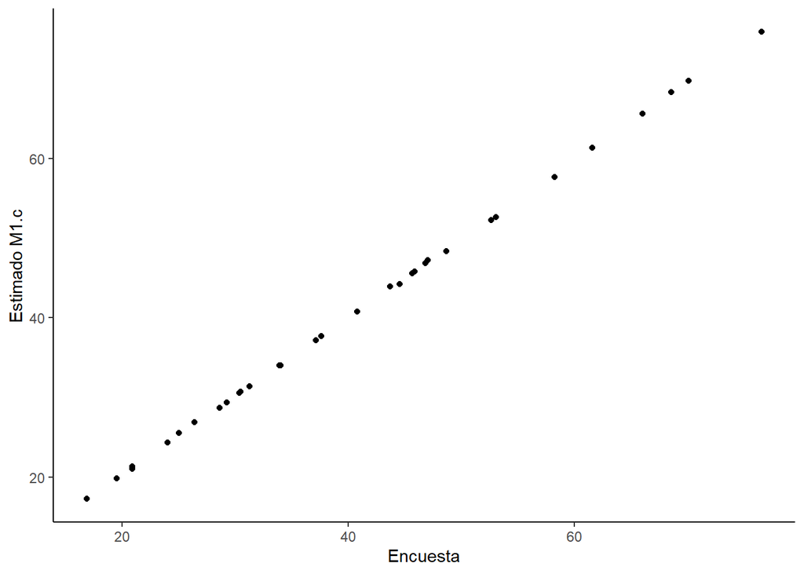

```r
ggplot(Prent, aes(SPent*100, M1.cPent*100)) + geom_point() + theme_classic() + labs(y="Estimado M1.c", x="Encuesta")
```

# Segundo ejemplo: Ordinal v multinomial

Cambiamos a `cumulative("logit")`

```r
D$i_privacion1<-D$i_privacion+1

M2<-brm(i_privacion1 ~ 1 + factor(niv_edexpjh) + tamhogesc + factor(tam_loc) + (1 | ent),
        prior = c(set_prior("normal(0,10)", class = "b"),
                  set_prior("normal(0,5)", class = "sd")),
        family=cumulative("logit", threshold="flexible"), chains=4, cores=4, iter=2000,  threads = threading(14, grainsize = 100),backend = "cmdstanr", data=D)
```

[output not shown]

[output cut: 43 more lines]

```
## Chain 1 Iteration: 2000 / 2000 [100%]  (Sampling)
## Chain 1 finished in 439.3 seconds.
## Chain 2 Iteration: 1800 / 2000 [ 90%]  (Sampling)
## Chain 4 Iteration: 1700 / 2000 [ 85%]  (Sampling)
## Chain 2 Iteration: 1900 / 2000 [ 95%]  (Sampling)
## Chain 4 Iteration: 1800 / 2000 [ 90%]  (Sampling)
## Chain 2 Iteration: 2000 / 2000 [100%]  (Sampling)
## Chain 2 finished in 474.6 seconds.
## Chain 4 Iteration: 1900 / 2000 [ 95%]  (Sampling)
## Chain 4 Iteration: 2000 / 2000 [100%]  (Sampling)
## Chain 4 finished in 491.9 seconds.
##
## All 4 chains finished successfully.
## Mean chain execution time: 455.2 seconds.
## Total execution time: 492.2 seconds.
```

```r
summary(M2)
```

```
##  Family: cumulative
##   Links: mu = logit; disc = identity
## Formula: i_privacion1 ~ 1 + factor(niv_edexpjh) + tamhogesc + factor(tam_loc) + (1 | ent)
##    Data: D (Number of observations: 19999)
##   Draws: 4 chains, each with iter = 2000; warmup = 1000; thin = 1;
##          total post-warmup draws = 4000
##
## Group-Level Effects:
## ~ent (Number of levels: 32)
##               Estimate Est.Error l-95% CI u-95% CI Rhat Bulk_ESS Tail_ESS
## sd(Intercept)     0.57      0.08     0.44     0.75 1.01      569     1127
##
## Population-Level Effects:
##                    Estimate Est.Error l-95% CI u-95% CI Rhat Bulk_ESS Tail_ESS
## Intercept[1]          -1.32      0.11    -1.54    -1.11 1.01      524     1034
## Intercept[2]           0.28      0.11     0.06     0.49 1.01      524      975
## Intercept[3]           1.73      0.11     1.51     1.95 1.01      532      952
## Intercept[4]           3.13      0.11     2.91     3.35 1.01      550     1051
## Intercept[5]           4.79      0.12     4.54     5.03 1.01      686     1267
## Intercept[6]           6.82      0.19     6.45     7.21 1.00     1113     1432
## factorniv_edexpjh1    -0.65      0.04    -0.73    -0.57 1.00     2281     2711
## factorniv_edexpjh2    -1.11      0.04    -1.18    -1.04 1.00     2241     2558
## factorniv_edexpjh3    -1.67      0.05    -1.76    -1.57 1.00     2445     2812
## factorniv_edexpjh4    -2.21      0.06    -2.33    -2.10 1.00     2678     2853
## tamhogesc              0.09      0.01     0.08     0.11 1.00     3551     2465
## factortam_loc2         0.35      0.05     0.26     0.44 1.00     2658     2789
## factortam_loc3         0.63      0.05     0.54     0.72 1.00     2787     2662
## factortam_loc4         1.07      0.03     1.00     1.14 1.00     2649     2596
##
## Family Specific Parameters:
##      Estimate Est.Error l-95% CI u-95% CI Rhat Bulk_ESS Tail_ESS
## disc     1.00      0.00     1.00     1.00   NA       NA       NA
##
## Draws were sampled using sample(hmc). For each parameter, Bulk_ESS
## and Tail_ESS are effective sample size measures, and Rhat is the potential
## scale reduction factor on split chains (at convergence, Rhat = 1).
```

En este caso `pp_check` lo hacemos con barras puesto que se trata de una variable de grupos

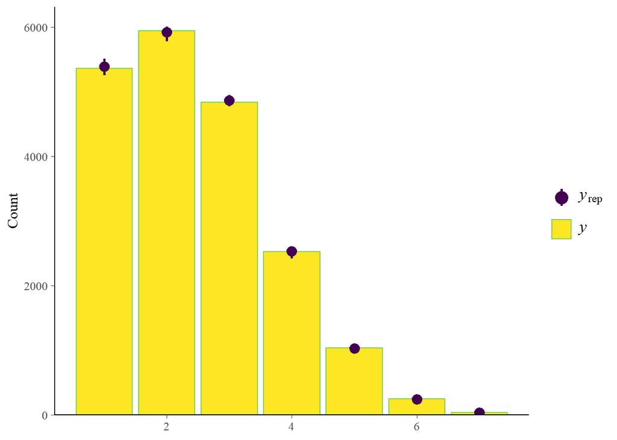

```r
pp_check(M2, nreps = 10, type = "bars")
```

También podemos hacerlo por algún tipo de variable

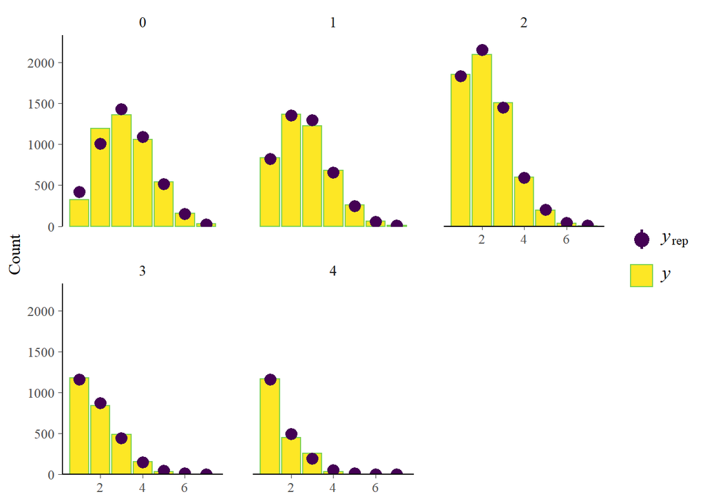

```r
pp_check(M2, type = "bars_grouped", group = "niv_edexpjh",
         nreps = 10)
```